Prototype for review · not approved · 2026-10-17

# In-app purchase, inside the iPhone app

How Papic credits, Live Watch and Event Hub Pro are bought **inside the iPhone app with Apple's own sheet**, once Apple approves the Paid Apps agreement (owner, 2026-10-08: *"if it goes approved, then we will add the apple payment on the app as well before apple check"*). The web keeps its apply-then-pay flow (GCash · BDO) untouched. Everything here is the **delta** on screens that already ship; each caption names what changed and what did not.

Theme

- **Rule 0, measured on origin/main:** `lib/store-shell.ts` hides every paid add-on in the app and refuses every purchase route; `apply-pro-sheet.tsx` passes no effects and no price in the app (`heldOnWeb`); `choose-plan-sheet.tsx` returns `null` in the app; `papic-buy-sheet.tsx` goes to `/pay`. PR #6420 (draft) makes More list only owned services. `apps/mobile` carries **no StoreKit or RevenueCat plugin yet**.
- **What this adds:** one native "buy" bridge in the Capacitor shell, three buy buttons that already exist pointed at it, one owned/not-owned read that is already the web's (`eventOwnsSku` over `orders`), and the honest states around Apple's sheet: success, pending, cancelled, failed, restore.
- **Apple's rules kept:** no price of ours, no link to the web, no GCash for a digital item inside the app (3.1.1 / 3.1.3). The supplier booking fee stays on GCash / BDO in the app (3.1.3(e)), as `storeShellRefusesPayable` already allows.

## Baseline — what ships today

Captured read-only from **www.setnayan.com/pricing** on 2026-10-17 at 375 px. These are the web's public price cards; the figures render live from the admin catalogue (`platform_retail_catalog_v2`). Nothing on this page invents a price: every ₱ below is one of these.

Web · Papic

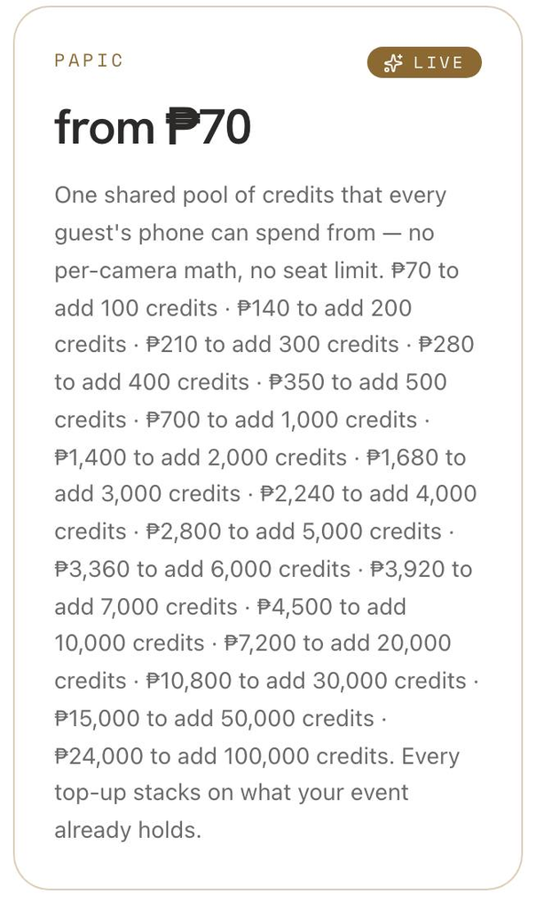

**Papic** — a shared pool of credits, 17 sizes from ₱70 (100 credits) to ₱24,000 (100,000 credits).

Web · Live Watch

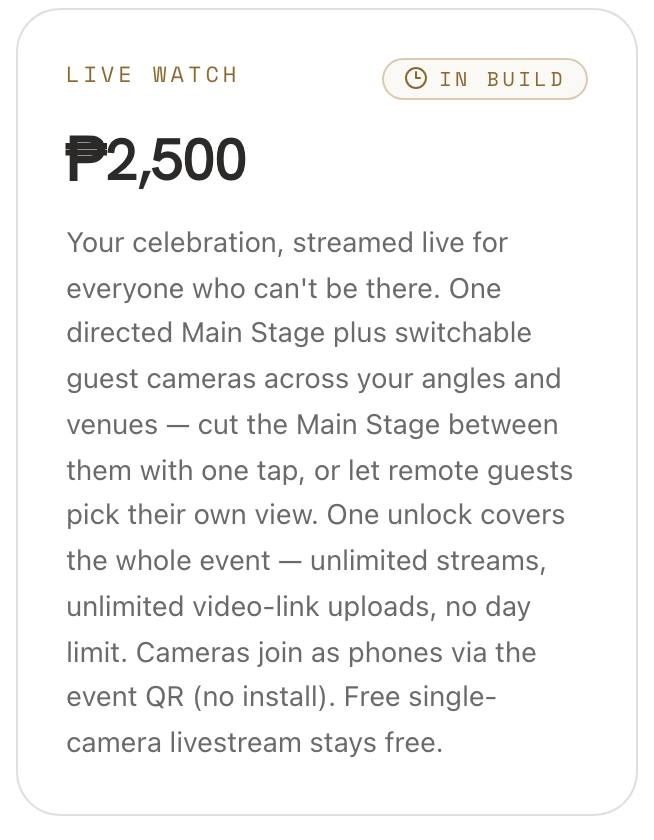

**Live Watch** — ₱2,500, one unlock for the whole event. The card still says "celebration" and "In build".

Web · Event Hub Pro

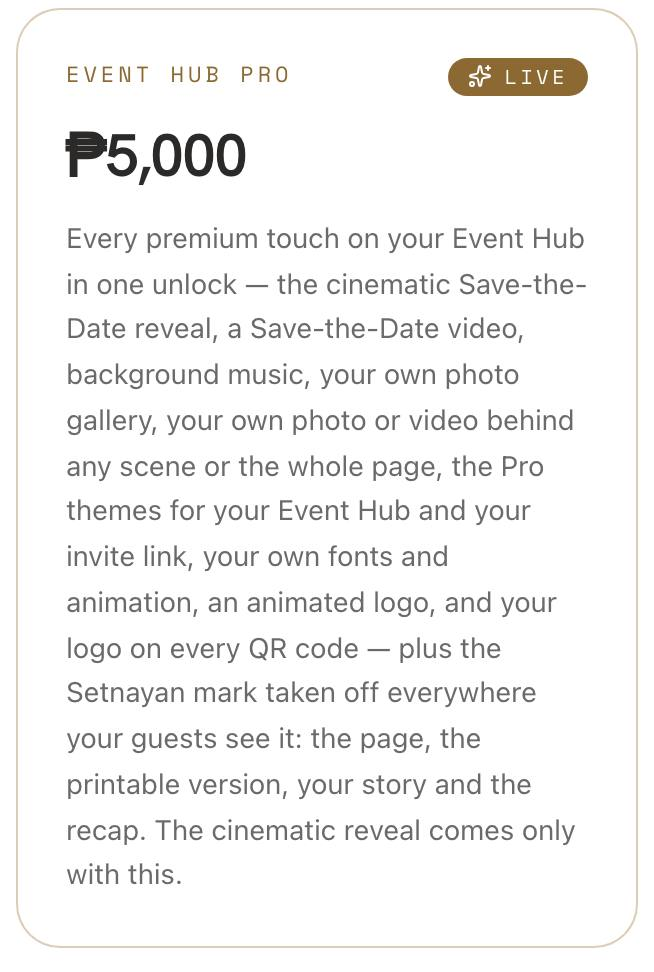

**Event Hub Pro** — ₱5,000, one unlock; on the web it is asked for at Apply in the Maker.

Web · Setnayan AI

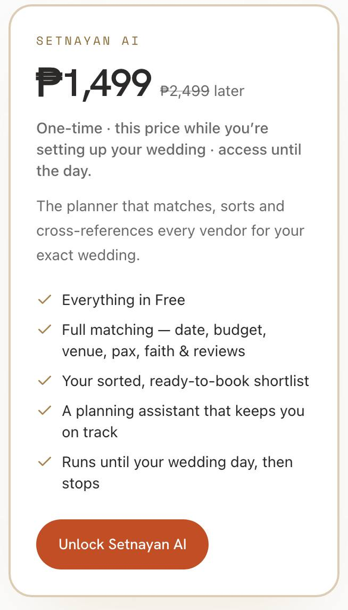

**Setnayan AI** — ₱1,499 (₱2,499 later), a per-user pass that runs until the day.

**Not captured:** the signed-in web sheets (Apply, Add credits, Live Watch's plan sheet, Home › Your services). They need a local dev server; this Mac was at load 22 when this page was drawn and no walk lane was free. The frames marked **"redrawn from source"** below reproduce the shipped component's own copy and structure from its file on origin/main, not a screenshot, and change only what the caption says.

## Today in the app

The store shell sells nothing and shows nothing paid. A deep link to any paid feature lands here.

### Today · /web-only

9:41

SetnayaniPhone app

#### Not available in the app

Setnayan for iPhone and Android

##### This part of Setnayan is not included in the app

The app covers planning your event — your guest list, seating, schedule, mood board, save-the-date and RSVP, and booking suppliers. This feature is not part of the app version.

Back to your dashboard

HomeGuestsEvent HubSuppliers

Redrawn from `app/(shell)/web-only/page.tsx`. **Unchanged.** It stays for the items that are NOT on IAP (Music Maker · Video booth · Thank-You Video · Supplier Pro). Four tabs: no More while nothing is owned (PR #6420).

## Where the buy button lives — three places, all already there

No shop tab, no catalogue page in the app. Pro is asked for at **Apply** (owner 2026-09-28 · 2026-09-30). Papic credits and Live Watch sit in **Home › Your services**, the quick-setup list the owner ruled on 2026-10-08, with the control in place. Each button opens Apple's sheet instead of `/pay`.

### 1 · Apply, in the app · Pro not owned

9:41

×Save-the-Date ▾Look ▾↶✓5

Save the date

Maria &  
Jose

are getting married

14 · February · 2027

Apply needs Event Hub Proⓘ

5 changes guests do not see yet. 2 of them are Pro:

- ◆**Velvet** · ThemeGo to ↗✕
- ◆**Rise** · Animation · ScheduleGo to ↗✕

Unlock Pro and Apply · ₱5,000 Apply without the Pro effects

One unlock for this event — it covers everyone on it.  
Billed by Apple to your Apple account.

Redrawn from `apply-pro-sheet.tsx`. **Changed:** the app now gets the effects list and the primary button (today it gets neither). The button opens **Apple's sheet**; the ₱ is the App Store price StoreKit returns, never typed, never the web's. Two new lines of fine print. Nothing says "website" or "cheaper".

### 2 · Home › Your services · in the app

9:41

HomeMaria & Jose · 120 days

Next

Send the invitations58 of 96 still to sendOpen

Your services

PlannerSetnayan AITry itActivate

Guest photosPapic320 credits left+ Buy more

Live streamLive WatchNot on yet · one camera is freeActivate

Paid · Still owing

₱48,000 paid₱92,000 still owing to 4 suppliersBudget

HomeGuestsEvent HubSuppliersMore

The quick-setup list the owner ruled (2026-10-08) — **not yet built on main**; Home today shows Papic and Setnayan AI rows (`home-first-screen.tsx`). **In the app:** the same rows, and the three IAP items keep their one control in place. Music Maker and Video booth rows appear **only once owned** (no IAP yet). No Event Hub Pro row (owner 2026-09-30). **Every number in the frame is a sample** (120 days · 58 of 96 · 320 credits · ₱48,000 / ₱92,000), as are "Maria & Jose".

### 3 · Papic · Add credits · in the app

9:41

HomeMaria & Jose · 120 days

Your services

Guest photos320 credits left

Add credits

You have **320 credits** now.

−**500 credits**₱350 · App Store price+

After this**820 credits**

Buy · ₱350✕ Not now

Credits land on this event the moment Apple confirms.

Redrawn from `papic-buy-sheet.tsx` + `papic-buy-form.tsx`. **Unchanged:** "Add credits", "You have N credits now", the − / + stepper, "After this". **Changed:** the stepper walks the **Apple products** (one per rung on sale), "Continue to payment" becomes **Buy · ₱** and opens Apple's sheet. The ₱ is Apple's, read live.

### 4 · Live Watch · Activate · in the app

9:41

HomeMaria & Jose · 120 days

Your services

Live streamNot on yet

Live Watch✕

One unlock covers the whole event — every stream, every camera, no day limit. Your free single camera stays free.

Your broadcast goes out on **your own YouTube**. YouTube needs a channel that is already cleared for live streaming — switching it on can take 24 hours.

✓I understand, and I already have a YouTube account that is ready for live streaming.

Add Live Watch · ₱2,500

Billed by Apple to your Apple account.

Redrawn from `choose-plan-sheet.tsx` as `live-studio-control/page.tsx` mounts it. **Unchanged:** the YouTube notice and the affirmative tick box that gates the button (owner 2026-09-02). **Changed:** the sheet no longer returns `null` in the app; the lead-time notice about "manual payment reconciliation" is dropped here (Apple confirms at once); the button opens Apple's sheet.

## Apple's sheet — not ours

iOS draws this. We cannot style it, word it or put our logo copy on it; we only name the product and Apple quotes its own PHP price point. Drawn here so the owner sees what the couple sees between our two screens.

### 5 · Apple's purchase sheet

9:41

×Save-the-Date ▾Look ▾↶✓5

Save the date

Maria &  
Jose

are getting married

Apple's sheet — not ours

App Store✕

S

Event Hub Pro

Setnayan · In-App Purchase

Accountm•••••a@icloud.com

Price**₱5,000.00**

**Double-click to pay**Confirm with Face ID

**Apple's.** The product name is ours ("Event Hub Pro" · "Papic · 500 credits" · "Live Watch"). The ₱ here is a placeholder for the **App Store price point the owner maps** to each item — Apple sells only at its tiers, and keeps 15% under the Small Business Program (owner applied 2026-10-08). Same sheet for all three items.

## After Apple's sheet — every outcome has its own honest screen

"Success" is said only when **our server** has verified Apple's transaction and switched the item on for the event (App Store Server Notifications → the same activation path the web's admin approval uses). Apple taking the money is **not** success yet; the screen says so.

### 6 · Success · Pro

9:41

×Save-the-Date ▾Look ▾↶✓

Save the date

Maria &  
Jose

are getting married

Event Hub Pro is on◆

For Maria & Jose's wedding, and everyone on it.

✓ Applied — all 5 changes, including Velvet and Rise.

Done

Your receipt comes from Apple.

**New.** Honours "KEEP, MARKED" (2026-10-08): the held ◆ changes apply in the same tap, nothing redone. The ✓ badge empties. Said only after our server confirmed the transaction.

### 7 · Pending · Apple paid, we're switching it on

9:41

HomeMaria & Jose · 120 days

Your services

Guest photos320 credits left

Switching it on…

Apple confirmed your purchase of **500 credits**. We're adding them to this event now — it usually takes a moment.

If they're not here in a few minutes, open **Profile › Restore purchases**. You will not be charged twice.

OK

**New.** The gap between Apple's confirmation and our server's verification is shown as what it is. No "Success" and no spinning forever (the "0% forever" disease, CLAUDE.md). Also the screen for Apple's **Ask to Buy**: "Waiting for your family organiser to approve — we'll switch it on when Apple tells us."

### 8 · Cancelled · nothing changed

9:41

×Save-the-Date ▾Look ▾↶✓5

Save the date

Maria &  
Jose

are getting married

Apply needs Event Hub Proⓘ

Nothing was charged. Your 2 Pro changes are still in your draft.

- ◆**Velvet** · ThemeGo to ↗✕
- ◆**Rise** · Animation · ScheduleGo to ↗✕

Unlock Pro and Apply · ₱5,000 Apply without the Pro effects

The couple closed Apple's sheet. **Back to the same Apply sheet** with one quiet line; both choices still there. No alert, no "error".

### 9 · Failed · Apple couldn't complete it

9:41

HomeMaria & Jose · 120 days

Your services

Live streamNot on yet

Live Watch✕

The App Store couldn't complete this purchase. Nothing was charged, and nothing changed on your event.

Check your Apple payment method, then try again.

Try again · ₱2,500Not now

Apple's error text is never shown raw. One sentence that says what is true: **nothing charged, nothing changed**. The button stays — Rule "Later never takes the buy away" (`later-never-takes-the-buy-away.test.ts`).

## Already owned — bought on the web, or on another phone

Ownership lives on the **event**, in `orders`, read by `eventOwnsSku` — the same read the web uses. An Apple purchase writes one more `orders` row (channel: App Store) and nothing else is new. So an item bought on the web **shows as owned in the app and works**, which is exactly what 3.1.3(b) allows once the same item is also sold by IAP. Owned is never sold twice.

### 10 · Apply · Pro owned (web or app)

9:41

×Save-the-Date ▾Look ▾↶✓5

Save the date

Maria &  
Jose

are getting married

Ready to apply✕

5 changes guests do not see yet. Apply puts them on your Event Hub.

- ◆Look · **Velvet**
- ◆Schedule · **Rise**
- Event Details · **Ceremony time**
- Look · **Buttons**
- Story · **How we met**

Apply

Exactly the shipped "Ready to apply" sheet (`none` branch). The ◆ rows wear the **unlocked** diamond, not the padlock. No price, no button — the app never offers Pro to an event that has it.

### 11 · Home · owned rows show as owned

9:41

HomeMaria & Jose · 120 days

Your services

PlannerSetnayan AIOnOpen

Guest photosPapic820 credits left+ Buy more

Live streamLive WatchOn · bought on the webGo live

MusicMusic MakerAdded to your eventOpen

HomeGuestsEvent HubSuppliersMore

Owned reads as owned, whichever side paid: Setnayan AI **On**, Live Watch **On · Go live**, Music Maker (web-only, owned) **appears because it is owned** (PR #6420). Only Papic keeps a buy — credits are consumable. More tab appears since something is owned. Sample figures (820 credits).

### 12 · Profile › Restore purchases

9:41

Profilemaria@…

Account

Name and photo›

Restore purchasesBought on another phone, or signed outRestore

Delete my account›

Restored

✓ Event Hub Pro · Maria & Jose's wedding

✓ Live Watch · Maria & Jose's wedding

Papic credits don't need restoring — they are kept on the event, never on the phone. Anything bought on the web was already here.

Done

**New row** on the shipped Profile page (Apple requires it). Restore asks Apple for this Apple ID's transactions and matches them to our `orders` rows; nothing found → "Nothing to restore — anything you bought is already on your event." Credits are consumables: Apple cannot restore them; our ledger is the record.

## What the app must NOT show

Guideline 3.1.1 (digital goods only via IAP) and 3.1.3 (no steering to another way to pay). Every line below is struck because it got an app rejected before (2026-06-30) or would.

### 13 · Struck — never in the app

9:41

Neverstore shell

Buy on setnayan.coma link, a QR or the words3.1.3

"₱5,000 on the web"any web price for a digital item3.1.3

Pay by GCash / BDOfor Pro, credits, Live Watch, AI3.1.1

/pricing · /papic · /panoodthe public price doorways3.1.3

"Cheaper on our site"or "save 15%", or a promo code to the web3.1.3

Supplier Pro · subscriptionstays web-only (owner 2026-10-08)3.1.1

A tour slide that sellsslides marked `sells` stay dropped3.1.1

Still allowed in the app

Supplier booking fee · GCash / BDOa real-world service (3.1.3(e)) — `storeShellRefusesPayable` already lets it through

The existing guards stay: `STORE_SHELL_WEB_ONLY_DOORWAYS`, `WEB_ONLY_PURCHASE_ROUTE`, `storeShellHidesHref`, the `sells` filter. What changes is only the **allow-list**: the three IAP items' controllers and sheets open in the app; everything else keeps landing on `/web-only`.

## Under the sheet — the one new bridge

- **One native plugin** in `apps/mobile` (StoreKit 2, via RevenueCat or Capacitor's own purchases plugin — builder's call) exposed to the web as `window.SetnayanIAP.buy(productId, eventId)` and `restore()`. The web only ever asks for an owner-named product id; it never knows a price until StoreKit answers.
- **Verification is server-side:** App Store Server Notifications v2 → our endpoint → verify the signed transaction → insert the `orders` row with status `paid` (the same status the admin stamps on a GCash order) → the existing activation path lights the feature. A refund notification sets `refunded` → `RELINQUISHED_STATUSES` already turns it off.
- **Product ids are per SKU:** `COUPLE_WEBSITE_PRO`, `LIVE_STUDIO`, and one per Papic rung on sale (`PAPIC_ONE_500`…). Setnayan AI waits (decision 1).
- **Prices stay the admin's on the web** and **Apple's in the app**. Two numbers, one item, never shown side by side.
- **Tests to copy:** `reads-are-honest.test.ts` (a failed read never renders as "not owned"), `later-never-takes-the-buy-away.test.ts`, `the-app-more-lists-only-owned-services.test.ts` (PR #6420) — extend, don't invent.

## Decisions for the owner

1. **Which items go on IAP first.** Recommend: Papic credits (consumable) · Event Hub Pro · Live Watch — the three with a buy button already in a shipped sheet. Setnayan AI second wave: it is a per-user pass with two prices ("₱1,499 now · ₱2,499 later") and a comeback window; Apple's shape for that is a non-renewing subscription, and its price can't change by countdown — it needs its own design. Supplier Pro stays web-only (your ruling).
2. **How Pro is sold in the app.** Recommend: only at Apply, as on the web (your 2026-09-30 ruling: no Pro card), one tap in the sheet → Apple's sheet → held ◆ changes applied at once. No Home row, no Pro page in the app.
3. **Apple's product type for Pro and Live Watch.** You said non-consumable for Live Watch. Recommend "consumable, applied to the event you're in" for both: Apple lets an Apple ID buy a non-consumable **once, ever** — a planner with a second event, or a couple's next event, could never buy it again, and Restore would move it to the wrong event. Ownership stays on the event in `orders`, which is already how the web works; Restore reads our ledger. Alternative: non-consumable, accepting one Pro per Apple ID for life.
4. **Price points and the 15%.** Apple sells only at its PHP price points and keeps 15% (Small Business Program, once approved). Recommend: map each item to the Apple point nearest **at or above** the admin catalogue price, and keep the web price as is — the app never shows the web's, so they need not match. Alternative: raise the web to match, one price everywhere.
5. **How many Papic rungs become Apple products.** The web ladder has 17 sizes. Recommend five: 100 · 500 · 1,000 · 5,000 · 10,000 credits — the stepper walks those; fewer products to price, review and keep in step with the admin ladder. Alternative: all 17, mirroring the web exactly.